# Analysis of a TCGA RNA-seq data set on Kidney Clear Cell Carcinoma

J. Sanchez, P. Badia and G. Palou

Master Programme on Bioinformatics for Health Sciences, Universitat Pompeu Fabra, Barcelona, Catalonia

javier.sanchez14@estudiant.upf.edu  
pau.badia01@estudiant.upf.edu  
guillermo.palou@upf.edu

junio 16, 2019

# 1 Introduction

Kidney Clear Cell Carcinoma or clear cell renal cell carcinoma (ccRCC), is a chemotherapy-resistant disease that can be distinguished of other cancer because affected cells show a clear cytoplasm, are surrounded by a distinct cell membrane and contain round and uniform nuclei. Inherited predisposition to ccRCC has been shown to arise from genes involved in regulating cellular metabolism, making ccRCC a model for the role of an oncologic-metabolic shift. The Cancer Genome Atlas (TCGA) has comprehensively profiled this type of cancer in a patient cohort. Here we analyze the expression profiles of those patients, accessible in the form of a raw RNA-seq counts produced by TCGA (2013) using a pipeline based on the R/Bioconductor software package `Rsubread`.

This document is written in [R markdown](https://rmarkdown.rstudio.com) and should be processed using R and you need to install the packages *knitr* and *markdown*. Moreover, it using the official style for Bioconductor vignettes facilitated by the Bioconductor package *BiocStyle*. Please consult that package documentation, and particularly the [vignette](http://bioconductor.org/packages/release/bioc/vignettes/BiocStyle/inst/doc/AuthoringRmdVignettes.html) on “Authoring R Markdown vignettes”, for full details on how to elaborate this kind of documents.

The specific instructions to generate the final HTML report are written in a Makefile. To run it you just need to type

`$ make`

on the unix shell. The `makefile` contains instructions to separately process the different files that integrate this report, and so only the file that has been modified will be rebuilt. If you wish to remove or add files to be processed, you should modify the `makefile`.

The directory `results` will contain resulting files produced during the analysis, however, figures are going to end by default directories associated with the source filenames from where they were created.

# 2 Quality analysis

Before starting, we need to import all the libraries that are going to be used in this analysis.

```r
library(knitr)
library(SummarizedExperiment)
library(edgeR)
library(geneplotter)
library(sva)
library(ggplot2)
library(GSVAdata)
library(GSEABase)
library(Category)
```

## 2.1 Data import

First, we import the dataset and store it in a `SummarizedExperiment` object, named `se`. This kind of object has genes on its rows and samples on its columns, 20115 genes and 614 samples in our case. Both of these entities have their own associated metadata, i.e., gene symbol, lenght and GC content for genes. For samples, there are more than 500 more fields, for instance type, gender and race.

```r
se <- readRDS(file.path("input","seKIRC.rds"))
se
```

```
## class: RangedSummarizedExperiment
## dim: 20115 614
## metadata(5): experimentData annotation cancerTypeCode
##   cancerTypeDescription objectCreationDate
## assays(1): counts
## rownames(20115): 1 2 ... 102724473 103091865
## rowData names(3): symbol txlen txgc
## colnames(614): TCGA.3Z.A93Z.01A.11R.A37O.07
##   TCGA.6D.AA2E.01A.11R.A37O.07 ... TCGA.CZ.5988.11A.01R.1672.07
##   TCGA.CZ.5989.11A.01R.1672.07
## colData names(549): type bcr_patient_uuid ...
##   lymph_nodes_aortic_pos_by_ihc lymph_nodes_aortic_pos_total
```

Next, we explore the dimensions of the column data of the `se` object, containing the samples data and we observe that it has 614 rows (samples) and 549 columns (metadata fields). To see the possible values that each clinical variable can have we use `mcols` function.

```r
dim(colData(se))
```

```
## [1] 614 549
```

```r
colData(se)[1:5, 1:5]
```

```
## DataFrame with 5 rows and 5 columns
##                                  type                     bcr_patient_uuid
##                              <factor>                             <factor>
## TCGA.3Z.A93Z.01A.11R.A37O.07    tumor 2B1DEA0A-6D55-4FDD-9C1C-0D9FBE03BD78
## TCGA.6D.AA2E.01A.11R.A37O.07    tumor D3B47E53-6F40-4FC8-B5A4-CBE548A770A9
## TCGA.A3.3306.01A.01R.0864.07    tumor 9fb55e0b-43d8-40a3-8ef2-d198e6290551
## TCGA.A3.3307.01A.01R.0864.07    tumor 7ac1d6c6-9ade-49af-8794-10b5b96b2b05
## TCGA.A3.3308.01A.02R.1325.07    tumor 3cbca837-f5a7-4a87-8f02-c59eac232d5a
##                              bcr_patient_barcode form_completion_date
##                                         <factor>             <factor>
## TCGA.3Z.A93Z.01A.11R.A37O.07        TCGA-3Z-A93Z           2014-11-11
## TCGA.6D.AA2E.01A.11R.A37O.07        TCGA-6D-AA2E            2014-3-17
## TCGA.A3.3306.01A.01R.0864.07        TCGA-A3-3306            2010-8-23
## TCGA.A3.3307.01A.01R.0864.07        TCGA-A3-3307            2010-4-13
## TCGA.A3.3308.01A.02R.1325.07        TCGA-A3-3308            2010-4-12
##                              prospective_collection
##                                            <factor>
## TCGA.3Z.A93Z.01A.11R.A37O.07                    YES
## TCGA.6D.AA2E.01A.11R.A37O.07                    YES
## TCGA.A3.3306.01A.01R.0864.07                     NO
## TCGA.A3.3307.01A.01R.0864.07                     NO
## TCGA.A3.3308.01A.02R.1325.07                     NO
```

```r
mcols(colData(se), use.names=TRUE)
```

```
## DataFrame with 549 rows and 2 columns
##                                                          labelDescription
##                                                               <character>
## type                                           sample type (tumor/normal)
## bcr_patient_uuid                                         bcr patient uuid
## bcr_patient_barcode                                   bcr patient barcode
## form_completion_date                                 form completion date
## prospective_collection            tissue prospective collection indicator
## ...                                                                   ...
## lymph_nodes_pelvic_pos_total                               total pelv lnp
## lymph_nodes_aortic_examined_count                           total aor lnr
## lymph_nodes_aortic_pos_by_he                          aln pos light micro
## lymph_nodes_aortic_pos_by_ihc                                 aln pos ihc
## lymph_nodes_aortic_pos_total                                total aor-lnp
##                                         CDEID
##                                   <character>
## type                                       NA
## bcr_patient_uuid                           NA
## bcr_patient_barcode                   2673794
## form_completion_date                       NA
## prospective_collection                3088492
## ...                                       ...
## lymph_nodes_pelvic_pos_total          3151828
## lymph_nodes_aortic_examined_count     3104460
## lymph_nodes_aortic_pos_by_he          3151832
## lymph_nodes_aortic_pos_by_ihc         3151831
## lymph_nodes_aortic_pos_total          3151827
```

These metadata consists of two columns of information about the clinical variables. One called `labelDescription` contains a succint description of the variable, often not more self-explanatory than the variable name itself, and the other called ‘CDEID’ corresponds to the so-called `Common Data Element (CDE)` identifier. This identifier can be use in https://cdebrowser.nci.nih.gov to search for further information about the associated clinical variable using the `Advanced search` form and the `Public ID` attribute search.

We do the same with the gene data and observe the metadata mentioned before.

```
## [1] 20115     3
```

```
## DataFrame with 20115 rows and 3 columns
##                symbol     txlen              txgc
##           <character> <integer>         <numeric>
## 1                A1BG      3322 0.564419024683925
## 2                 A2M      4844 0.488232865400495
## 9                NAT1      2280 0.394298245614035
## 10               NAT2      1322 0.389561270801815
## 12           SERPINA3      3067 0.524942940984676
## ...               ...       ...               ...
## 100996331       POTEB      1706 0.430832356389215
## 101340251    SNORD124       104 0.490384615384615
## 101340252   SNORD121B        81 0.407407407407407
## 102724473      GAGE10       538 0.505576208178439
## 103091865   BRWD1-IT2      1028 0.592412451361868
```

To perform quality assessment and normalization we use the edgeR R/Bioconductor package and create a `DGEList` objec, which we are going to save in the file `dge.rds`.

```r
dge <- DGEList(counts=assays(se)$counts, genes=mcols(se))
saveRDS(dge, file.path("results", "dge.rds"))
```

## 2.2 Within-sample normalization

Now we calculate $\log_2$ CPM values of expression and put them as an additional assay element to ease their manipulation.

```r
assays(se)$logCPM <- cpm(dge, log=TRUE, prior.count=0.5)
assays(se)$logCPM[1:5, 1:5]
```

```
##    TCGA.3Z.A93Z.01A.11R.A37O.07 TCGA.6D.AA2E.01A.11R.A37O.07
## 1                      3.681094                     1.308506
## 2                     11.070451                     9.467119
## 9                     -6.544714                    -6.544714
## 10                    -6.544714                    -6.544714
## 12                     5.196098                     5.386859
##    TCGA.A3.3306.01A.01R.0864.07 TCGA.A3.3307.01A.01R.0864.07
## 1                    -0.2268151                     0.203261
## 2                     9.8676287                    11.166993
## 9                    -6.5447145                    -6.544714
## 10                   -6.5447145                    -6.544714
## 12                    4.6330031                     5.479129
##    TCGA.A3.3308.01A.02R.1325.07
## 1                     0.2380578
## 2                    11.2922910
## 9                    -6.5447145
## 10                   -6.5447145
## 12                    5.8638782
```

## 2.3 Filtering of sequencing depth (first filtering)

We then examine the sequencing depth in terms of total number of sequence read counts mapped to the genome per sample and filter those samples that have less than 20M reads, with the goal of having samples with a sufficient amount of reads so meaningful inferences can be made from this analysis. This filtering removes 13 samples from our dataset, leaving a total of 601 samples. We then save the new filtered `se` and `dge` objects with new names, `.filt`.

```r
cpm_cutoff <- 20
mask <- colSums(assays(se)$counts)/1e6 > cpm_cutoff
se.filt <- se[, mask]
dge.filt <- dge[, mask]
dim(se.filt)
```

```
## [1] 20115   601
```

## 2.4 Paired samples selection (second filtering)

We now select the paired samples from the dataset, i.e., individuals from which there are both tumorous and healthy tissue samples, since the comparison of these kind of samples will give more statistical power to our analysis and will allow to control non-biological sources of variation. This step removes most of the samples, leaving a total of 142 samples, 71 tumorous and 71 healthy, i.e., each one of them coming from a different individual, 71 individuals. We then save the new filtered `se` and `dge` objects with new names, `.filt2`.

```r
normal_IDs <- substr(colnames(se.filt[,se.filt$type=="normal"]),1,12)
tumor_IDs <- substr(colnames(se.filt[,se.filt$type=="tumor"]),1,12)
IDs <- substr(colnames(se.filt),1,12)
paired_mask <- IDs %in% normal_IDs & IDs %in% tumor_IDs
se.filt2 <- se.filt[,paired_mask]
dge.filt2<- dge.filt[, paired_mask]
colData(se.filt2)[1:5,1:5]
```

```
## DataFrame with 5 rows and 5 columns
##                                  type                     bcr_patient_uuid
##                              <factor>                             <factor>
## TCGA.A3.3358.01A.01R.1541.07    tumor 8a575e00-5dc5-416d-a8f5-2cdfb8e62c31
## TCGA.A3.3387.01A.01R.1541.07    tumor 9dc7812b-c7a2-4de4-bf6d-4c7261384a62
## TCGA.B0.4700.01A.02R.1541.07    tumor e33dff22-5bf1-4dd8-bed7-063cb555677c
## TCGA.B0.4712.01A.01R.1503.07    tumor 3f72d63f-ad48-4500-baf6-897b1d6dda7d
## TCGA.B0.5402.01A.01R.1503.07    tumor d7ab7ec0-3de7-4ffd-a5ac-f75579355b2a
##                              bcr_patient_barcode form_completion_date
##                                         <factor>             <factor>
## TCGA.A3.3358.01A.01R.1541.07        TCGA-A3-3358            2011-3-17
## TCGA.A3.3387.01A.01R.1541.07        TCGA-A3-3387            2011-3-17
## TCGA.B0.4700.01A.02R.1541.07        TCGA-B0-4700            2011-8-26
## TCGA.B0.4712.01A.01R.1503.07        TCGA-B0-4712            2011-3-29
## TCGA.B0.5402.01A.01R.1503.07        TCGA-B0-5402            2011-3-31
##                              prospective_collection
##                                            <factor>
## TCGA.A3.3358.01A.01R.1541.07        [Not Available]
## TCGA.A3.3387.01A.01R.1541.07        [Not Available]
## TCGA.B0.4700.01A.02R.1541.07                     NO
## TCGA.B0.4712.01A.01R.1503.07                     NO
## TCGA.B0.5402.01A.01R.1503.07                     NO
```

## 2.5 Distribution of sequencing depth

```r
ord <- order(dge.filt2$sample$lib.size)
summary(dge.filt2$sample$lib.size/1e+06)
```

```
##    Min. 1st Qu.  Median    Mean 3rd Qu.    Max.
##   25.82   40.83   51.42   50.75   58.22   81.86
```

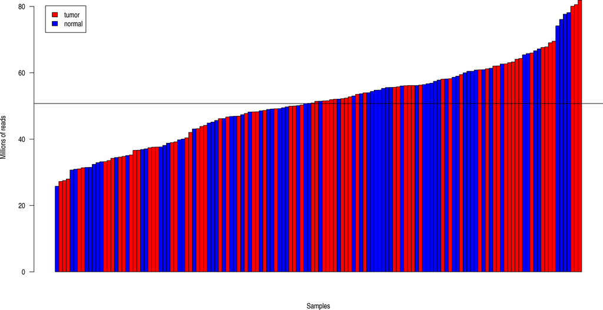

Figure 1: Library sizes in increasing order

```r
barplot(dge.filt2$sample$lib.size[ord]/1e+06, las = 1, ylab = "Millions of reads", xlab = "Samples", col = c("red", "blue")[se.filt2$type[ord]], space=c(0,0))
legend("topleft", c("tumor", "normal"), fill = c("red", "blue"), inset = 0.02)
abline(h=(sum(colSums(assays(se.filt2)$counts))/1e6)/ncol(se.filt2))
```

Figure 1 shows the sequencing depth per sample, also known as library size, in increasing order. There is a good distribution of tumor and normal samples with different sequencing depth. However, there is a huge difference between some samples, taking into account that the average is around 50 million reads. However, this will not affect the results, since 20M is an acceptable library size.

We store un-normalized data from the paired samples filtered by sequencing depth (cutoff of 20 CPM).

```r
saveRDS(se.filt2, file.path("results", "se.filt2.unnorm.rds"))
saveRDS(dge.filt2, file.path("results", "dge.filt2.unnorm.rds"))
```

## 2.6 Distribution of expression levels among samples

We look at the distribution of expression values per sample in terms of logarithmic CPM units using geneplotter R/Bioconductor package.

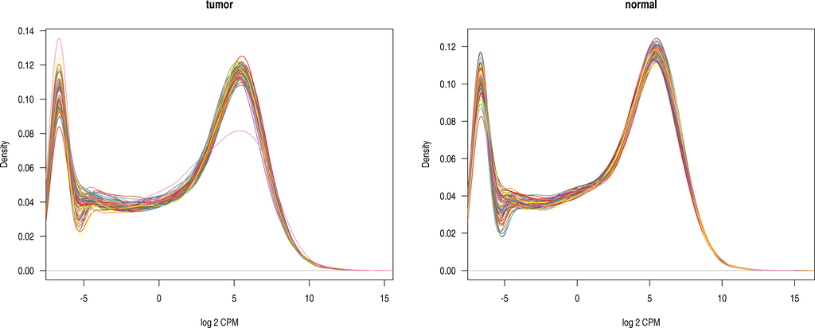

Figure 2: Non-parametric density distribution of expression profiles per sample

```r
assays(se.filt2)$logCPM <- cpm(dge.filt2, log=TRUE, prior.count=0.5)
par(mfrow=c(1, 2))
multidensity(as.list(as.data.frame(assays(se.filt2[, se.filt2$type == "tumor"])$logCPM)),
             xlab="log 2 CPM", legend=NULL, main="tumor", las=1)
multidensity(as.list(as.data.frame(assays(se.filt2[, se.filt2$type == "normal"])$logCPM)),
             xlab="log 2 CPM", legend=NULL, main="normal", las=1)
```

Figure 2 shows that the normal samples have a good logCPM distribution, but some of the tumor samples seem to have a distinct RNA composition. Let’s see if this can be fixed later on by filtering.

## 2.7 Distribution and filtering of expression levels among genes (third filtering)

Now we calculate the average expression per gene through all the samples, and plot the distribution of expression levels across genes (Figure 3). It allows us to identify lowly expressed genes.

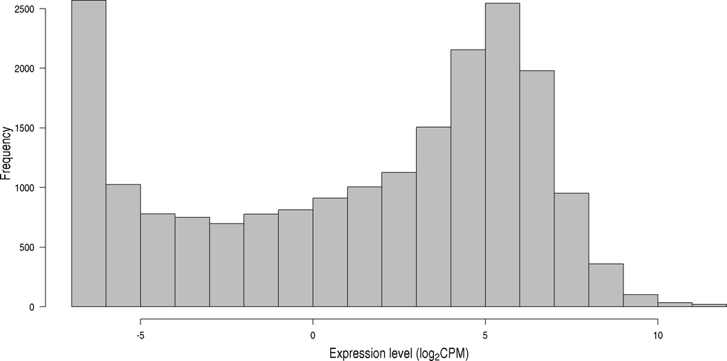

Figure 3: Distribution of average expression level per gene

```r
avgexp <- rowMeans(assays(se.filt2)$logCPM)
par(mar = c(4, 5, 1, 1))
h <- hist(avgexp, xlab = expression("Expression level (" * log[2] * "CPM)"), main = "",
    las = 1, col = "grey", cex.axis = 1.2, cex.lab = 1.5)
```

RNA-seq expression profiles from lowly-expressed genes can lead to artifacts in downstream differential expression analyses. For this reason, we remove them following this criteria:

- Filter out genes with fewer than a given number of samples meeting a minimum expression (logCPM) cut-off.

In our case, the minimum logCPM is 0.6 in at least 71 samples, which is the sample size of the control group.

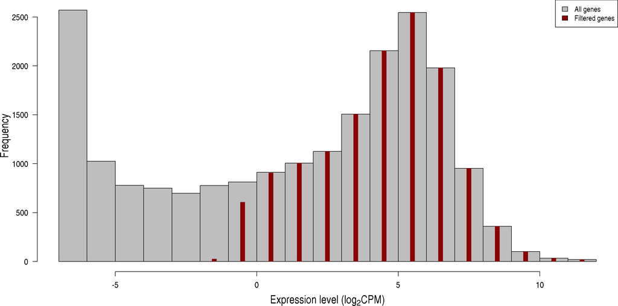

Figure 4: Distribution of average expression level per gene, showing the filtered genes in red

```r
# CPM cutoff
cpm_cutoff <- round(15/min(dge.filt2$samples$lib.size/1e+06), digits = 1)
nsamplescutoff <- min(table(se.filt2$type))
mask <- rowSums(cpm(dge.filt2) > cpm_cutoff) >= nsamplescutoff
se.filt3 <- se.filt2[mask, ]
dge.filt3 <- dge.filt2[mask, ]

# Plot
par(mar = c(4, 5, 1, 1))
h <- hist(avgexp, xlab = expression("Expression level (" * log[2] * "CPM)"), main = "",
    las = 1, col = "grey", cex.axis = 1.2, cex.lab = 1.5)
x <- cut(rowMeans(assays(se.filt3)$logCPM), breaks = h$breaks)
lines(h$mids, table(x), type = "h", lwd = 10, lend = 1, col = "darkred")
legend("topright", c("All genes", "Filtered genes"), fill = c("grey", "darkred"))
```

We store the un-normalized versions of the data filtered by gene expression (cutoff of 0.6 logCPM expressed in at least 71 samples).

```r
saveRDS(se.filt3, file.path("results", "se.filt3.unnorm.rds"))
saveRDS(dge.filt3, file.path("results", "dge.filt3.unnorm.rds"))
```

## 2.8 Between-sample normalization

We calculate now the normalization factors on the filtered expression data set and compare the corresponding plot (Figure 5 rigth) with the unnormalized expression data set (Figure 5 left).

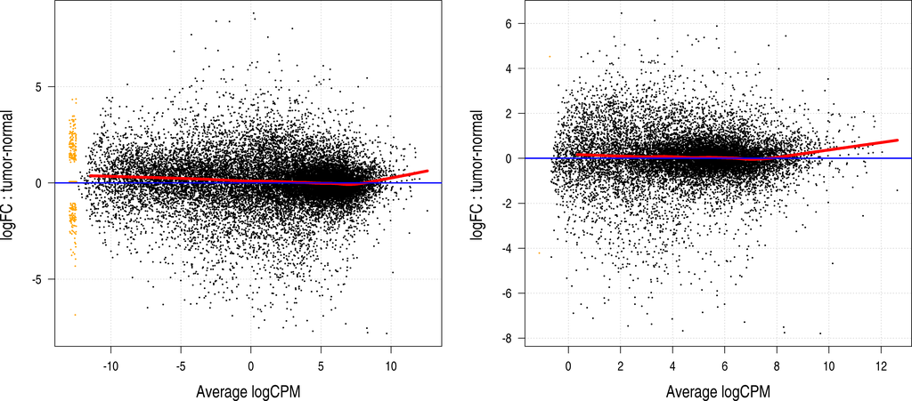

Figure 5: Normalized filtered expression data (right) and unnormalized unfiltered expression data (left)

```r
#Unnormalized first filtered data set
par(mfrow = c(1, 2))
dge.filt2$samples$group <- se.filt2$type
plotSmear(dge.filt2, lowess = TRUE, las = 1, cex.lab = 1.5, cex.axis = 1.2)
abline(h = 0, col = "blue", lwd = 2)
#Normalized second filtered dataset
dge.filt3 <- calcNormFactors(dge.filt3)
dge.filt3$samples$group <- se.filt3$type
plotSmear(dge.filt3, lowess = TRUE, las = 1, cex.lab = 1.5, cex.axis = 1.2)
abline(h = 0, col = "blue", lwd = 2)
```

```r
assays(se.filt3)$logCPM <- cpm(dge.filt3, log=TRUE, prior.count=0.5)
```

two previous artifacts can be observed in the unnormalized data (Figure 5 left):

1. A majority of genes seem to be upregulated under a condition where we do not expect it.
2. Large fold changes tend to occur at low expression levels (orange color in the left plot), because ratios between low numbers may easy lead to large fold-changes.

After the normalization on the filtered expression data we correct both of them (Figure 5 rigth): the first one by means of the between-sample normalization, and the second one by the filtration of lowly-expressed genes.

## 2.9 Batch Identification

Using the TCGA barcode from the samples we can asses whether the plate identifier, tissue source site, portion analyte, sample vial and center can work as surrogates for batch effect indicators.

```r
tss <- substr(colnames(se.filt3), 6, 7)
center <- substr(colnames(se.filt3), 27, 28)
plate <- substr(colnames(se.filt3), 22, 25)
portionanalyte <- substr(colnames(se.filt3), 18, 20)
samplevial <- substr(colnames(se.filt3), 14, 16)

table(data.frame(TYPE=se.filt2$type, TSS=tss))
```

```
##         TSS
## TYPE     A3 B0 B2 B8 CJ CW CZ
##   normal  2 15  2  5 10 10 27
##   tumor   2 15  2  5 10 10 27
```

```r
table(data.frame(TYPE=se.filt2$type, CENTER=center))
```

```
##         CENTER
## TYPE     07
##   normal 71
##   tumor  71
```

```r
table(data.frame(TYPE=se.filt2$type, PLATE=plate))
```

```
##         PLATE
## TYPE     1277 1325 1503 1541 1672 1758 1858
##   normal    0    0   22   30   15    3    1
##   tumor     1    2   22   30   16    0    0
```

```r
table(data.frame(TYPE=se.filt2$type, SAMPLEVIAL=samplevial))
```

```
##         SAMPLEVIAL
## TYPE     01A 01B 11A
##   normal   0   0  71
##   tumor   70   1   0
```

```r
table(data.frame(TYPE=se.filt2$type, PORTIONANALYTE=portionanalyte))
```

```
##         PORTIONANALYTE
## TYPE     01R 02R 11R
##   normal  68   3   0
##   tumor   31   7  33
```

We can see that the distribution of the samples across the different variables is quite uniform, since they are paired samples, however some of them are not balanced, such as samplevial and portion analyte. We will not remove any samples, since we are going to include these variables in our model and adjust for them in case they produce a batch effect, so the inferences about differential gene expression are accurate.

## 2.10 Batch effect: hierarchical clustering (fourth filtering)

We perform a hierarchical clustering of the samples indicating the batch to which each of them belongs to, to check if there is still some batch that might be confounding the outcome of interest.

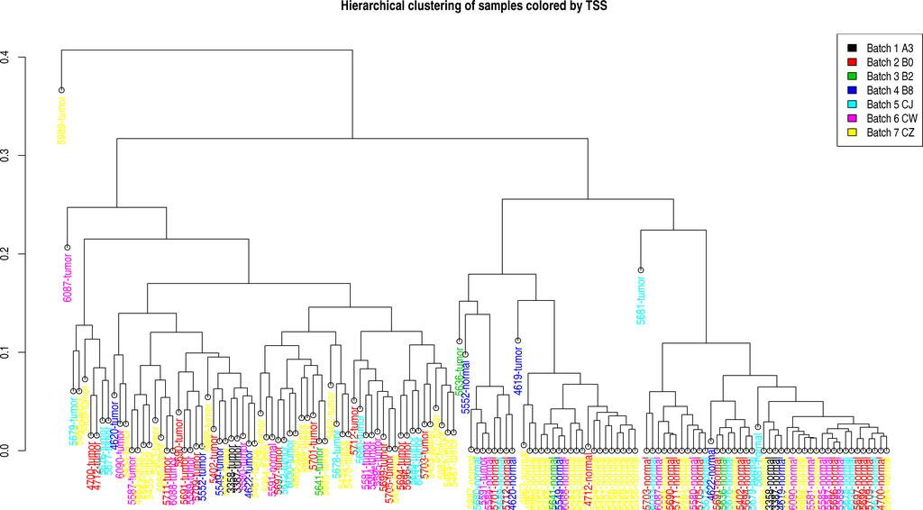

Figure 6: Hierarchical clustering of the samples, colored by Tissue Source Site (TSS)

```r
logCPM <- cpm(dge.filt3, log=TRUE, prior.count=3)
d <- as.dist(1-cor(logCPM, method="spearman"))
sampleClustering <- hclust(d)

## Batch: Tissue Source Site (TSS)
batch <- as.integer(factor(tss))
sampleDendrogram <- as.dendrogram(sampleClustering, hang=0.1)
names(batch) <- colnames(se.filt3)
outcome <- paste(substr(colnames(se.filt3), 9, 12), as.character(se.filt3$type), sep="-")
names(outcome) <- colnames(se.filt3)
sampleDendrogram <- dendrapply(sampleDendrogram,
                               function(x, batch, labels) {
                                 if (is.leaf(x)) {
                                   attr(x, "nodePar") <- list(lab.col=as.vector(batch[attr(x, "label")]))
                                   attr(x, "label") <- as.vector(labels[attr(x, "label")])
                                 }
                                 x
                               }, batch, outcome)
plot(sampleDendrogram, main="Hierarchical clustering of samples colored by TSS")
legend("topright", paste("Batch", sort(unique(batch)), levels(factor(tss))), fill=sort(unique(batch)))
```

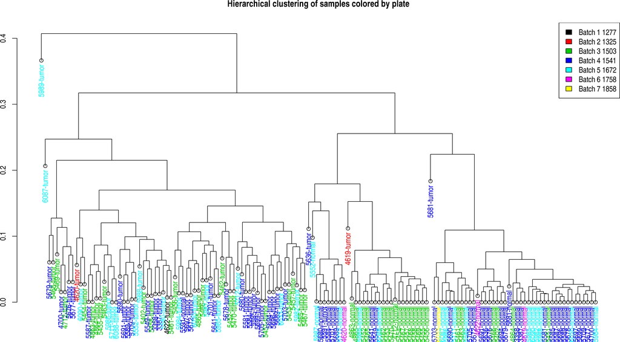

Figure 7: Hierarchical clustering of the samples, colored by Plate

```r
## Batch: Plate
batch <- as.integer(factor(plate))
sampleDendrogram <- as.dendrogram(sampleClustering, hang=0.1)
names(batch) <- colnames(se.filt3)
outcome <- paste(substr(colnames(se.filt3), 9, 12), as.character(se.filt3$type), sep="-")
names(outcome) <- colnames(se.filt3)
sampleDendrogram <- dendrapply(sampleDendrogram,
                               function(x, batch, labels) {
                                 if (is.leaf(x)) {
                                   attr(x, "nodePar") <- list(lab.col=as.vector(batch[attr(x, "label")]))
                                   attr(x, "label") <- as.vector(labels[attr(x, "label")])
                                 }
                                 x
                               }, batch, outcome)
plot(sampleDendrogram, main="Hierarchical clustering of samples colored by plate")
legend("topright", paste("Batch", sort(unique(batch)), levels(factor(plate))), fill=sort(unique(batch)))
```

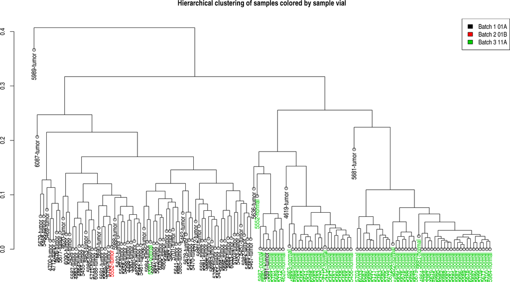

Figure 8: Hierarchical clustering of the samples, colored by Sample Vial

```r
## Batch: Sample Vial
batch <- as.integer(factor(samplevial))
sampleDendrogram <- as.dendrogram(sampleClustering, hang=0.1)
names(batch) <- colnames(se.filt3)
outcome <- paste(substr(colnames(se.filt3), 9, 12), as.character(se.filt3$type), sep="-")
names(outcome) <- colnames(se.filt3)
sampleDendrogram <- dendrapply(sampleDendrogram,
                               function(x, batch, labels) {
                                 if (is.leaf(x)) {
                                   attr(x, "nodePar") <- list(lab.col=as.vector(batch[attr(x, "label")]))
                                   attr(x, "label") <- as.vector(labels[attr(x, "label")])
                                 }
                                 x
                               }, batch, outcome)
plot(sampleDendrogram, main="Hierarchical clustering of samples colored by sample vial")
legend("topright", paste("Batch", sort(unique(batch)), levels(factor(samplevial))), fill=sort(unique(batch)))
```

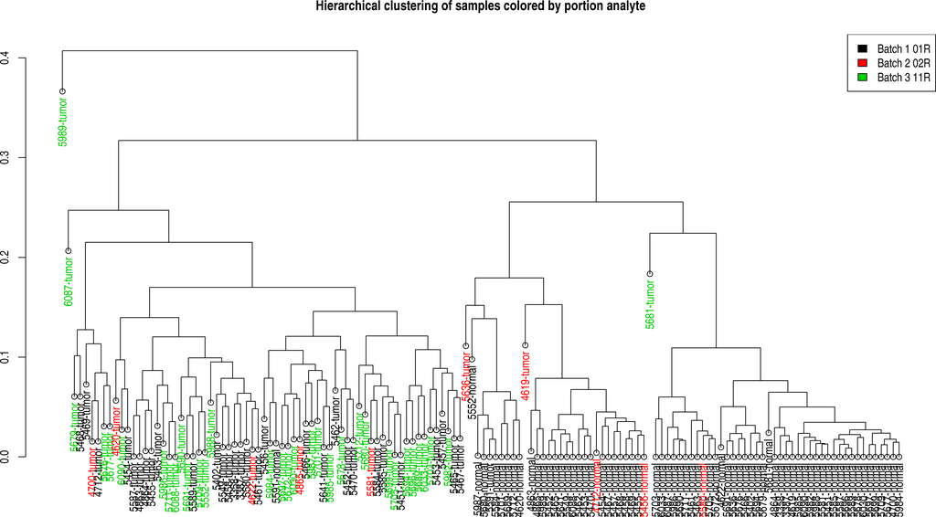

Figure 9: Hierarchical clustering of the samples, colored by Portion Analyte

```r
## Batch: Portion annalyte
batch <- as.integer(factor(portionanalyte))
sampleDendrogram <- as.dendrogram(sampleClustering, hang=0.1)
names(batch) <- colnames(se.filt3)
outcome <- paste(substr(colnames(se.filt3), 9, 12), as.character(se.filt3$type), sep="-")
names(outcome) <- colnames(se.filt3)
sampleDendrogram <- dendrapply(sampleDendrogram,
                               function(x, batch, labels) {
                                 if (is.leaf(x)) {
                                   attr(x, "nodePar") <- list(lab.col=as.vector(batch[attr(x, "label")]))
                                   attr(x, "label") <- as.vector(labels[attr(x, "label")])
                                 }
                                 x
                               }, batch, outcome)
plot(sampleDendrogram, main="Hierarchical clustering of samples colored by portion analyte")
legend("topright", paste("Batch", sort(unique(batch)), levels(factor(portionanalyte))), fill=sort(unique(batch)))
```

The first two dendograms of TSS (figure 6) and plate (figure 7) seem to confirm the absence of any batch effect. However, sample vial (figure 8) and portion analyte (figure 9) do produce a big clustering between normal and tumor samples. This will be take into account when doing the linear regression model. Moreover, there are 4 pairs of samples that are suspicious, this is 4 tumor samples that cluster with the normal ones: 4619, 5636, 5681 and 5591. We can see that the normal 5591 sample clusters perfectly with the tumor samples, so we deduced that this could be a labeling error. The other three, however have both their normal and tumor samples clustering with the normal ones. This could maybe mean that these tumor samples are in an early stage of the cancer development. Moreover, on the tumor samples, we have two clear outliers, 5989 and 6087, whose normal samples do not cluster unappropiately. For inference reasons, we discarded all of these samples and saved them in another object. This leaves us with 65 paired samples (130 in total).

```r
se.filt4 <- se.filt3[,grep("5591|5636|4619|5681|6087|5989", colnames(se.filt3), invert=TRUE)]
dge.filt4 <- dge.filt3[,grep("5591|5636|4619|5681|6087|5989", colnames(dge.filt3), invert=TRUE)]
se.dis <- se.filt3[,grep("5591|5636|4619|5681|6087|5989", colnames(se.filt3))]

assays(se.filt4)$logCPM <- cpm(dge.filt4, log=TRUE, prior.count=0.5)

tss2 <- substr(colnames(se.filt4), 6, 7)
plate2 <- substr(colnames(se.filt4), 22, 25)
portionanalyte2 <- substr(colnames(se.filt4), 18, 20)
samplevial2 <- substr(colnames(se.filt4), 14, 16)

dim(dge.filt4)
```

```
## [1] 13330   130
```

```r
table(se.filt4$type)
```

```
##
## normal  tumor
##     65     65
```

```r
table(data.frame(TYPE=se.filt4$type, TSS=tss2))
```

```
##         TSS
## TYPE     A3 B0 B2 B8 CJ CW CZ
##   normal  2 15  1  4  9  8 26
##   tumor   2 15  1  4  9  8 26
```

```r
table(data.frame(TYPE=se.filt4$type, PLATE=plate2))
```

```
##         PLATE
## TYPE     1277 1325 1503 1541 1672 1758 1858
##   normal    0    0   22   27   13    2    1
##   tumor     1    1   22   27   14    0    0
```

```r
table(data.frame(TYPE=se.filt4$type, SAMPLEVIAL=samplevial2))
```

```
##         SAMPLEVIAL
## TYPE     01A 01B 11A
##   normal   0   0  65
##   tumor   64   1   0
```

```r
table(data.frame(TYPE=se.filt4$type, PORTIONANALYTE=portionanalyte2))
```

```
##         PORTIONANALYTE
## TYPE     01R 02R 11R
##   normal  62   3   0
##   tumor   30   5  30
```

## 2.11 Batch effect: Multidimensional scaling

Now we make use of multidimensional scaling plots to check, first if there is a batch effect by gender, and second other potential variables that might be a new outcome of interest in tumor samples: cancer stage, tumor grade, cancer laterality, and vital status

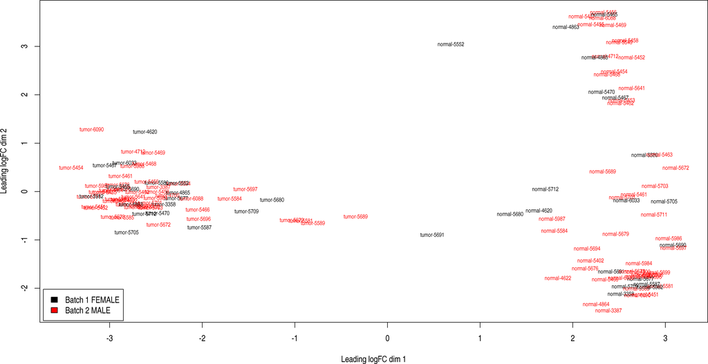

Figure 10: Multidimensional Scaling Plot for the batch effect of Gender

```r
tumor_se <- se.filt4[,se.filt4$type == "tumor"]
tumor_dge <- dge.filt4[,se.filt4$type == "tumor"]

## Gender
se_gender <- se.filt4[,!is.na(se.filt4$gender)]
dge_gender <- dge.filt4[,!is.na(se.filt4$gender)]
batch <- as.integer(factor(se_gender$gender))
outcome <- paste(factor(se_gender$type), substr(colnames(dge_gender), 9, 12), sep="-")
plotMDS(dge_gender, col = batch,labels = outcome, cex = 0.7)
legend("bottomleft", paste("Batch", sort(unique(batch)), levels(factor(se_gender$gender))), fill=sort(unique(batch)), inset=0.005)
```

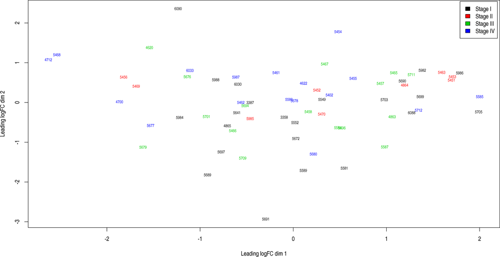

Figure 11: Multidimensional Scaling Plot for the outcome of interest Cancer Stage

```r
## Cancer stage

tumor_stage_se <- tumor_se[,!is.na(tumor_se$ajcc_pathologic_tumor_stage)]
tumor_stage_dge <-tumor_dge[,!is.na(tumor_se$ajcc_pathologic_tumor_stage)]
batch <- as.integer(factor(tumor_stage_se$ajcc_pathologic_tumor_stage))
outcome <- substr(colnames(tumor_stage_dge), 9, 12)
plotMDS(tumor_stage_dge, col = batch,labels = outcome, cex = 0.7)
legend("topright", sort(unique(batch)), levels(factor(tumor_stage_se$ajcc_pathologic_tumor_stage)), fill=sort(unique(batch)), inset=0.005)
```

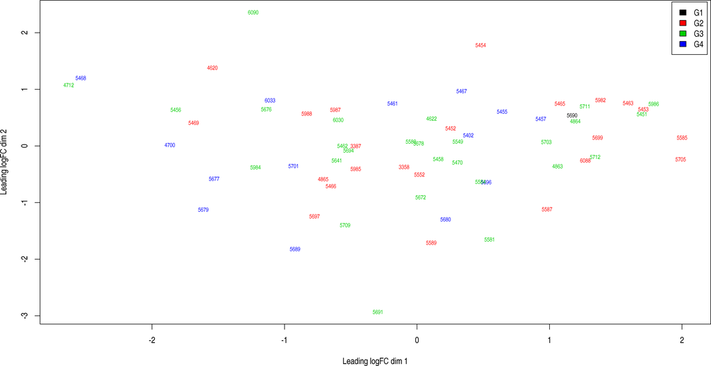

Figure 12: Multidimensional Scaling Plot for for the outcome of interest Tumor Grade

```r
## Tumor grade
tumor_grade_se <- tumor_se[,!is.na(tumor_se$tumor_grade)]
tumor_grade_dge <-tumor_dge[,!is.na(tumor_se$tumor_grade)]
batch <- as.integer(factor(tumor_grade_se$tumor_grade))
outcome <- substr(colnames(tumor_grade_dge), 9, 12)
plotMDS(tumor_grade_dge, col = batch,labels = outcome, cex = 0.7)
legend("topright", sort(unique(batch)), levels(factor(tumor_grade_se$tumor_grade)), fill=sort(unique(batch)), inset=0.005)
```

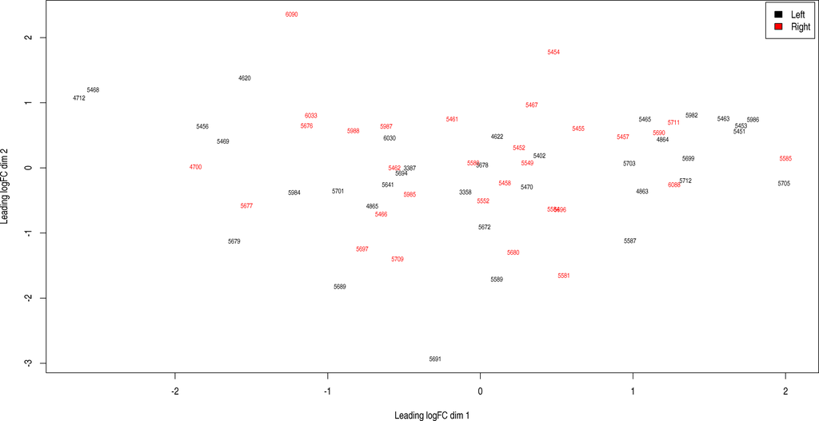

Figure 13: Multidimensional Scaling Plot for for the outcome of interest Cancer Laterality

```r
## Cancer laterality
tumor_late_se <- tumor_se[,!is.na(tumor_se$laterality)]
tumor_late_dge <-tumor_dge[,!is.na(tumor_se$laterality)]
batch <- as.integer(factor(tumor_late_se$laterality))
outcome <- substr(colnames(tumor_late_dge), 9, 12)
plotMDS(tumor_late_dge, col = batch,labels = outcome, cex = 0.7)
legend("topright", sort(unique(batch)), levels(factor(tumor_late_se$laterality)), fill=sort(unique(batch)), inset=0.005)
```

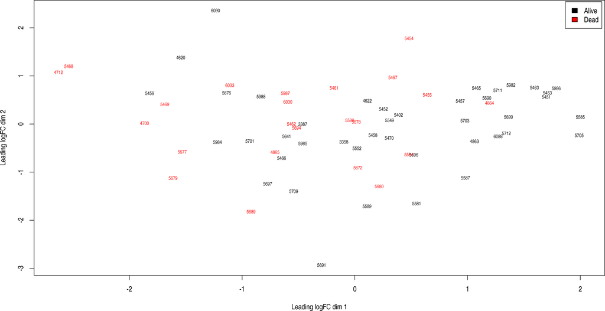

Figure 14: Multidimensional Scaling Plot for for the outcome of interest Vital Status

```r
## Vital status
tumor_status_se <- tumor_se[,!is.na(tumor_se$vital_status)]
tumor_status_dge <-tumor_dge[,!is.na(tumor_se$vital_status)]
batch <- as.integer(factor(tumor_status_se$vital_status))
outcome <- substr(colnames(tumor_status_dge), 9, 12)
plotMDS(tumor_status_dge, col = batch,labels = outcome, cex = 0.7)
legend("topright", sort(unique(batch)), levels(factor(tumor_status_se$vital_status)), fill=sort(unique(batch)), inset=0.005)
```

The first plot (figure 10) shows that there is no correlation between the gender and the logFC for the genes among the samples, which clusters them according to the outcome of interest (tumor or normal), for males and females are uniformly distributed among the two groups, considereing that there are more males than females.The rest of the plots (figures 11, 12, 13, 14) do not show any cluster by the new outcomes of interest in the tumor samples, thus might not be significant gene expression differences among the groups in the four variables.

# 3 Differential gene expression

Once all the data is properly filtered, we perform an examination of expression changes and their associated p-values using the limma and sva R/bionconductor packages. We first create a `linear regression model` and adjust for covariates. The covariates are the variables that can confound the outcome of interest, that is, a variable whose presence affects the variable being studied so that the results do not reflect the actual relationship. The known covariates are the ones that produces batch effect, among others, in our case these are portion analyte and sample vial. Moreover, as we have done a paired design, we need to add the patient ID (or the barcode, which in this case is the same as it is unique for each patient) in the model. Nevertheless, once we add the patient barcode, the rest of covariables such as portion analyte and sample vial are already corrected, because both normal and tumor samples are from the same patient. Exists surrogate variables, which are also sources of hereogeneity in high-throughput profiling data, that we cannot be aware of. Even so, we can adjust for these unkown covariates using `surrogate variable analysis` (SVA). Then, we calculate moderated t-statistics for differential gene expression, with a FDR cutoff of 0.01. Of note is that, we use `limma-voom`, instead of `limma-trend`, because we have a important differences in sequencing depth between samples, as voom estimates the mean-variance relationship at gene-by-sample level.

## 3.1 Linear Regression Model and adjustment for known and unkown covariates

```r
# Creating the linear regression model and adjusting for covariates (which are already corrected by adding the patient barcode for the paired design)
mod <- model.matrix(~factor(se.filt4$type) + factor(se.filt4$bcr_patient_barcode) , colData(se.filt4))
mod0 <- model.matrix(~factor(se.filt4$bcr_patient_barcode), colData(se.filt4))
# Adjusting for unkown covariates
sv <- sva(assays(se.filt4)$logCPM, mod = mod, mod0 = mod0)
```

```
## Number of significant surrogate variables is:  10
## Iteration (out of 5 ):1  2  3  4  5
```

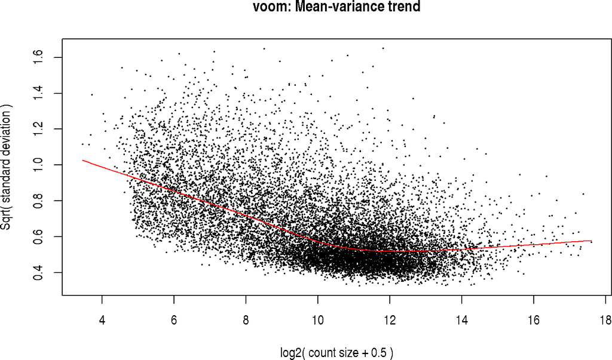

```r
#sv$n
mod <- cbind(mod, sv$sv)
colnames(mod) <- c(colnames(mod)[1:66], paste0("SV", 1:sv$n))
# Limma Voom
v <- voom(dge.filt4, mod, plot=TRUE)
```

```r
# Calculating t-statistics
fit <- lmFit(v, mod)
fit <- eBayes(fit)
# Adding genes metadata
genesmd <- data.frame(chr = as.character(seqnames(rowRanges(se.filt4))), symbol = rowData(se.filt4)[,1], logCPM = as.numeric(rowMeans(assays(se.filt4)$logCPM)),stringsAsFactors = FALSE)
fit$genes <- genesmd
# Fetching the table of results
tt <- topTable(fit, coef = 2, n = Inf)
FDRcutoff <- 0.01
# Examine the extent of differential expression at 1% FDR:
res <- decideTests(fit, p.value = FDRcutoff)
#summary(res)

# Calculating the number of DEGs genes
sum(tt$adj.P.Val<FDRcutoff)
```

```
## [1] 10824
```

```r
# Filter out DEGs by FDR and logFC
tt.filt <- tt[tt$adj.P.Val < FDRcutoff,]
DEgenes <- tt.filt[tt.filt$logFC >= 2 | tt.filt$logFC <= -2 ,]
# Number of filtered DEGs
length(DEgenes$symbol)
```

```
## [1] 1411
```

```r
# Number of upregulated DEGs
length(rownames(DEgenes[DEgenes$logFC >= 2,]))
```

```
## [1] 676
```

```r
# Number of downregulated DEGs
length(rownames(DEgenes[DEgenes$logFC <= -2,]))
```

```
## [1] 735
```

```r
# Table with complete results from all DEGs
head(DEgenes[order(abs(DEgenes$logFC),decreasing=TRUE),],10)
```

```
##          chr  symbol      logCPM      logFC     AveExpr         t
## 400713 chr19  ZNF880  6.15388137 -11.728764  6.17133634 -21.09196
## 361    chr18    AQP4  5.16499499 -11.616053  5.19025130 -22.12914
## 125875 chr19  CLDND2  1.50216473 -10.968431  1.53776690 -28.15034
## 8649    chr4 LAMTOR3  4.11100275 -10.540223  4.12470225 -23.49562
## 2592    chr9    GALT  2.05327871 -10.441964  2.07580549 -26.97673
## 391196  chr1   OR2M7  1.04417781 -10.243640  1.07679642 -28.44491
## 115825 chr13   WDFY2  2.88087990 -10.026435  2.90387623 -28.04175
## 8087    chr3    FXR1  0.61513628  -9.900432  0.62610627 -31.35443
## 6729   chr14   SRP54  5.89133521  -9.852930  5.89582216 -22.36069
## 54836   chr9   BSPRY -0.08327164  -9.774598 -0.05767394 -35.10187
##             P.Value    adj.P.Val        B
## 400713 1.072906e-28 1.414623e-27 55.11289
## 361    9.204607e-30 1.448612e-28 57.58350
## 125875 2.967334e-35 1.569625e-33 70.06435
## 8649   4.149114e-31 8.495805e-30 60.67468
## 2592   2.880064e-34 1.188584e-32 67.84566
## 391196 1.699112e-35 9.679128e-34 70.58179
## 115825 3.649118e-35 1.878098e-33 69.90782
## 8087   8.908131e-38 9.895449e-36 75.70664
## 6729   5.386510e-30 8.831756e-29 58.08306
## 54836  1.888212e-40 5.136709e-38 81.59129
```

```r
# Checking the number of DEGs in each chromosome
#sort(table(DEgenes$chr[tt$adj.P.Val < FDRcutoff]), decreasing = TRUE)
```

There are 10824 (from 13330) differentially expressed genes (DEGs) at FDR threshold of 0.01, which accounts for 81% of all the genes in the dataset. Adding a second filter of logFC > 2 or < -2, leaves us with 1411 DEGs (11% from the total). From these DEGs, 676 are upregulated and 735 are downregulated. We can visualize the results plotting a `volcanot plot` for these DEGs, a histogram for the raw p-values and a `qqplot` for t-statistics.

## 3.2 Volcano plot for DEGs, p-values histogram, t-statistics QQplot

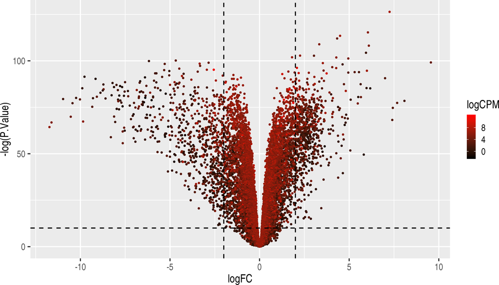

Figure 15: Volcano Plot for all DEGs

```r
# Volcano plot for all genes
ggplot(data=tt) +
theme_grey(base_size = 22) +
geom_point(aes(x=logFC,y=-log(P.Value),color=logCPM)) +
scale_colour_gradientn(colours=c("#000000" ,"#FF0000" ))+
geom_hline(yintercept=10, linetype="dashed", color = "black",size=1)+
geom_vline(xintercept = 2, linetype="dashed",
                color = "black", size=1)+
  geom_vline(xintercept = -2, linetype="dashed",
                color = "black", size=1)
```

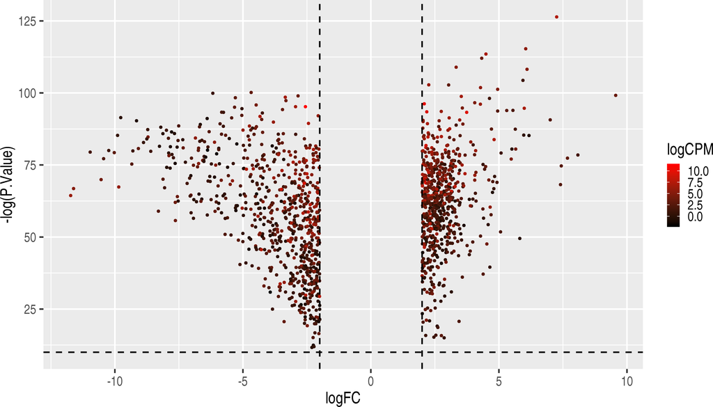

Figure 16: Volcano Plot for DEGs passing both thresholds

```r
# Volcanot plot for only DEGs with more than 2 abs(logFC)
ggplot(data=DEgenes) +
theme_grey(base_size = 22) +
geom_point(aes(x=logFC,y=-log(P.Value),color=logCPM)) +
scale_colour_gradientn(colours=c("#000000" ,"#FF0000" ))+
geom_hline(yintercept=10, linetype="dashed", color = "black",size=1)+
geom_vline(xintercept = 2, linetype="dashed",
                color = "black", size=1)+
  geom_vline(xintercept = -2, linetype="dashed",
                color = "black", size=1)
```

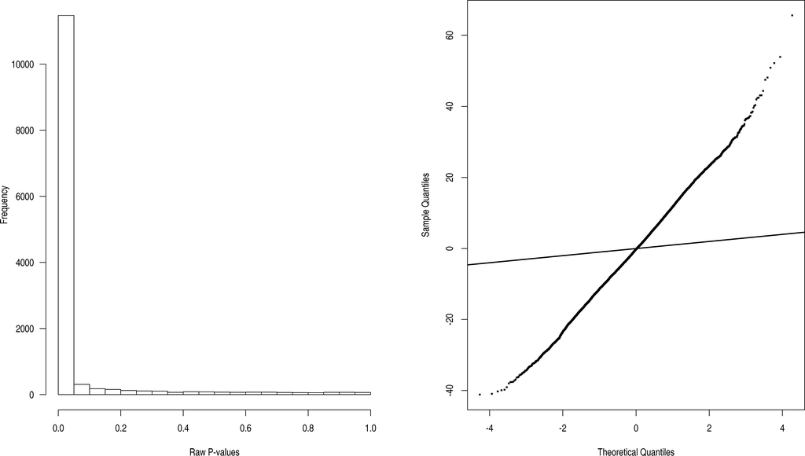

Figure 17: P-values histogram and t-statistics QQplot

```r
# Histogram for the p-values and qqplot for t-statistics
par(mfrow = c(1, 2), mar = c(4, 5, 2, 2))
hist(tt$P.Value, xlab = "Raw P-values", main = "", las = 1)
qqt(fit$t[, 2], df = fit$df.prior + fit$df.residual, main = "", pch = ".", cex = 3)
abline(0, 1, lwd = 2)
```

Figure 17, left, from above shows the distribution of the resulting raw p-values. An expected peak is below the significant 0.01 threshold of a p-value, while the rest of non-significant p-values remains with a uniform distribution. The QQplot from figure 17, right, shows that the vast majority of observed t-statistics do not follow its expected value (diagonal), thus, the t-statistics distribution is not normal, confirming the previous plot, where most of the genes are differentially expressed. This is actually somehow expected, as in cancer the control of the cell is completely altered and only few genes remains with the same level of expression as in a normal cell.

```r
#mnb <- rowRanges(se.filt2)$symbol == "AMPK"
#se.filt2[mnb,]
#mean(assays(se.filt2)$logCPM["7428",])
#mask <- Im[,"72"] == 1
#Im[mask,"72"]
```

# 4 Functional analysis by Gene Set Enrichment Analysis (GSEA)

## 4.1 Mean shift detection (Z-score)

We performed a functional analysis using `Gene Set Enrichment Analysis (GSEA)` to annotate which pathways are enriched by our list of DEGs. This analysis can be done in the GSEABase R/Bioconductor package. We could have done a `GO` or `GSVA` analysis as another alternatives but we decided to do GSEA instead. The databases used were from `KEGG`, `BIOCARTA` and `REACTOME`. The reason is because these are the most wide used databases in the current literature, and it would be more difficult to make an analysis interpretation and corroborate our results with the articles having pathways from other databases. In addition, we set a gene set minimum size of 5 genes, to be more reliable. However, we lowered the threshold to 3 to catch up a few other pathways that were interesting for ccRCC, although their interpretation should be cautelous, as they are not as reliable. `Z-score` and its associated p-value (and adjusted by FDR at 1% ) were calculated for each pathway.

```r
# Create a gene set using all DEGs (not a necessary step)
GS <- GeneSet(EntrezIdentifier("org.Hs.eg.db"), geneIds = rownames(DEgenes), setName = "ccRCC")
#details(GS)

# Replace given IDs by Entrez IDs for all the genes
GSsym <- mapIdentifiers(GS, SymbolIdentifier())
#GSsym[1:10]

# Obtain all human gene sets from GSVAdata package
data(c2BroadSets)
#c2BroadSets
#length(c2BroadSets)

# Restrict this analysis to pathways from KEGG, REACTOME and BIOCARTA: ###
c2BroadSets <- c2BroadSets[c(grep("^KEGG", names(c2BroadSets)),
grep("^REACTOME", names(c2BroadSets)), grep("^BIOCARTA", names(c2BroadSets)))]
#length(c2BroadSets)

# Join all human gene sets with the DEGs gene set
gsc <- GeneSetCollection(c(c2BroadSets, GS))
#gsc

# Create the incidence matrix indicating what genes belong to what gene set
Im <- incidence(gsc)
#dim(Im)
#Im[1:2, 1:10]

# We discard genes (columns in Im) that do not form part of our data
Im <- Im[, colnames(Im) %in% rownames(DEgenes)]
#dim(Im)

# Require gene sets with a minimum size of 5 genes: (change to 3 if needed)
Im <- Im[rowSums(Im) >= 3, ]
dim(Im)
```

```
## [1]  381 1411
```

```r
Im[1:5,1:5]
```

```
##                                      5162 5161 125 3098 126
## KEGG_GLYCOLYSIS_GLUCONEOGENESIS         1    1   1    1   1
## KEGG_CITRATE_CYCLE_TCA_CYCLE            1    1   0    0   0
## KEGG_FRUCTOSE_AND_MANNOSE_METABOLISM    0    0   0    1   0
## KEGG_GALACTOSE_METABOLISM               0    0   0    1   0
## KEGG_FATTY_ACID_METABOLISM              0    0   1    0   1
```

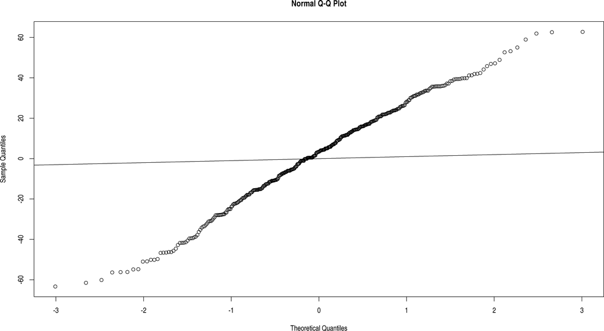

Figure 18: Z-scores QQplot

```r
# Store all moderated t-statistics for the genes forming the incidence matrix of gene sets
tGSgenes <- DEgenes[match(colnames(Im), rownames(DEgenes)), "t"]
#length(tGSgenes)
#head(tGSgenes)

# Calculate the Zs statistic
zS <- sqrt(rowSums(Im)) * (as.vector(Im %*% tGSgenes)/rowSums(Im))
#length(zS)
#head(zS)

# QQ plot of gene set Z-scores
qqnorm(zS)
abline(0, 1)
```

```r
# Sort the gene sets by Z-score
rnkGSz <- sort(abs(zS), decreasing = TRUE)
rnkGSzs <- as.data.frame(sort(abs(zS), decreasing = TRUE))
colnames(rnkGSzs) <- "z-score"
#rnkGSzs
#head(rnkGSz)

# Perform one sample z-test by calculating p-values
pv_zs <- pmin(pnorm(zS), 1 - pnorm(zS))
# Number of pathways: 207 (gene set size of 5) or 381 (gene set size of 3)
length(zS)
```

```
## [1] 381
```

```r
# Number of pathways upregulated/downregulated: 83/124 (gene set size of 5) or 211/170 (gene set size of 3)
table(zS>0)
```

```
##
## FALSE  TRUE
##   170   211
```

```r
# Number of pathways significantly enriched (p-value < 0.05): 187 (gene set size of 5) or 354 (gene set size of 3)
sum(pv_zs < 0.05)
```

```
## [1] 354
```

```r
# FDR multiple test correction
pvadj_zs <- p.adjust(pv_zs, method = "fdr")
# Number of pathways significantly enriched (FDR < 0.01): 187 (gene set size of 5) or 353 (gene set size of 3)
sum(pvadj_zs < 0.01)
```

```
## [1] 353
```

```r
rnkGSpz <- as.data.frame(sort(pvadj_zs, decreasing = FALSE))
colnames(rnkGSpz) <- "p-value"
#rnkGSpz

# Merge both Z-score and P-values dataframes into one
DEgs_z<- merge(rnkGSzs,rnkGSpz,by="row.names")
colnames(DEgs_z) <- c("pathways","z-score","Z_p-value")
head(DEgs_z[order(DEgs_z$`z-score`,decreasing=TRUE),],10)
```

```
##                                              pathways  z-score Z_p-value
## 163                           KEGG_RETINOL_METABOLISM 63.35540         0
## 115                   KEGG_HEMATOPOIETIC_CELL_LINEAGE 62.80567         0
## 147                           KEGG_PATHWAYS_IN_CANCER 62.61618         0
## 121                   KEGG_JAK_STAT_SIGNALING_PATHWAY 61.94537         0
## 365              REACTOME_TIGHT_JUNCTION_INTERACTIONS 61.52028         0
## 92               KEGG_DRUG_METABOLISM_CYTOCHROME_P450 60.11065         0
## 89        KEGG_CYTOKINE_CYTOKINE_RECEPTOR_INTERACTION 58.97800         0
## 144                    KEGG_OXIDATIVE_PHOSPHORYLATION 56.36021         0
## 110                   KEGG_GLYCOLYSIS_GLUCONEOGENESIS 56.22086         0
## 131 KEGG_METABOLISM_OF_XENOBIOTICS_BY_CYTOCHROME_P450 56.16869         0
```

```r
#write.csv(as.data.frame(DEgs), file = "GSEA_Zscore_5size.csv")
```

In the `c2BroadSets` object there are 833 pathways (from KEGG, BIOCARTA and REACTOME). Depending on the gene set size threshold used we remove more or less pathways:

-Gene set minimum size of 5 genes –> 207 pathways left, from wich 187 were significantly enriched (FDR < 0.01)

-Gene set minimum size of 3 genes –> 381 pathways left, from wich 353 were significantly enriched (FDR < 0.01)

We discuss the GSEA results in the report. A QQplot (figure 18) shows a good distribution of the Z-scores.

For some of the most enriched (and/or meaningful) gene sets we can make a scatter plot of the mean expression values comparing tumor vs normal.

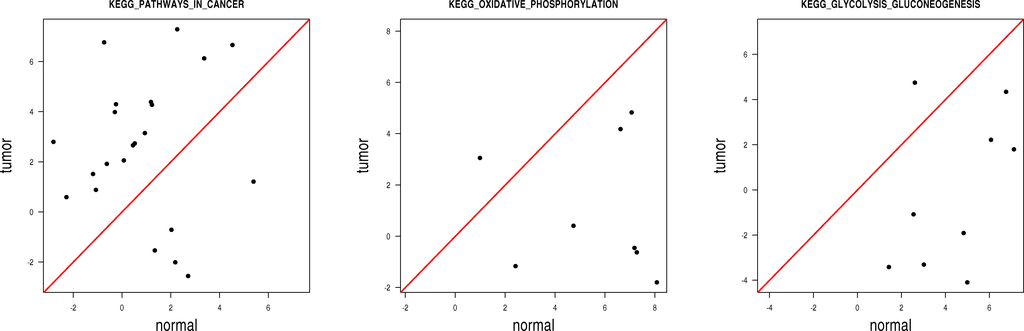

Figure 19: Scatter Plots for some interesting pathways with high Z-score

```r
# Scatter plot
plotGS <- function(se, gs, pheno, ...) {
l <- levels(colData(se)[, pheno])
idxSamples1 <- colData(se)[, pheno] == l[1]
idxSamples2 <- colData(se)[, pheno] == l[2]
exps1 <- rowMeans(assays(se)$logCPM[gs, idxSamples1])
exps2 <- rowMeans(assays(se)$logCPM[gs, idxSamples2])
rng <- range(c(exps1, exps2))
plot(exps1, exps2, pch = 21, col = "black", bg = "black", xlim = rng, ylim = rng,
xlab = l[1], ylab = l[2], ...)
abline(a = 0, b = 1, lwd = 2, col = "red")
}

# Vector with indices (from rnkGSz list) of interesting pathways
pathways <- c(3,6,7,8,9,25,29,30,31,33,41,34,35,49,51,105,111,150,178)

# Plotting only some examples

par(mfrow = c(1, 3), mar = c(4, 5, 3, 4))
genesGS1 <- colnames(Im)[which(Im[names(rnkGSz)[3], ] == 1)]
genesGS2 <- colnames(Im)[which(Im[names(rnkGSz)[8], ] == 1)]
genesGS3 <- colnames(Im)[which(Im[names(rnkGSz)[9], ] == 1)]
plotGS(se.filt4, genesGS1, "type", main = names(rnkGSz)[3], cex.lab = 2, las = 1)
plotGS(se.filt4, genesGS2, "type", main = names(rnkGSz)[8], cex.lab = 2, las = 1)
plotGS(se.filt4, genesGS3, "type", main = names(rnkGSz)[9], cex.lab = 2, las = 1)
```

```r
# For loop to plot all interesting pathways
#for (i in pathways){
  #genesGS1 <- colnames(Im)[which(Im[names(rnkGSz)[i], ] == 1)]
  #plotGS(se.filt4, genesGS1, "type", main = names(rnkGSz)[i], cex.lab = 2, las = 1)
#}
```

These scatter plots (figure 19) helps to decide whether the pathway is upregulated (the majority of the genes are above the diagonal) or downregulated (the majority of the genes are below the diagonal).

## 4.2 Change in scale detection (X2-score)

The previous GSEA analysis using Z-score detects shifts in mean expression. However, if half of the genes are up-regulated and the other half down-regulated, the mean shift cancels out. This is what is known as a change in scale. To detect such a change we should rather use the `X2-score`.

We created a data frame containing all pathways with the Z-score and $X^2$-score (and its associated p-values). The interpretation is in the report.

```r
#X2-score calculation
xS <- applyByCategory(tGSgenes, Im, function(x) (sum((x - mean(x))^2) - (length(x) - 1))/(2 *(length(x) - 1)))

# Sort the gene sets by X2-score
rnkGSx <- sort(abs(xS), decreasing = TRUE)
rnkGSxs <- as.data.frame(sort(abs(xS), decreasing = TRUE))
colnames(rnkGSxs) <- "X2-score"
#head(rnkGSxs,25)

# Perform one sample z-test by calculating p-values
pv_xs <- pmin(pnorm(xS), 1 - pnorm(xS))
# Number of pathways: 207 (gene set size of 5) or 381 (gene set size of 3)
length(rnkGSx)
```

```
## [1] 381
```

```r
# Number of pathways significantly enriched (p-value < 0.05): 207 (gene set size of 5) or 381 (gene set size of 3)
sum(pv_xs < 0.05)
```

```
## [1] 378
```

```r
# FDR multiple test correction
pvadj_xs <- p.adjust(pv_xs, method = "fdr")
# Number of pathways significantly enriched (FDR < 0.01): 207 (gene set size of 5) or 381 (gene set size of 3)
sum(pvadj_xs < 0.01)
```

```
## [1] 375
```

```r
rnkGSpx <- as.data.frame(sort(pvadj_xs[which(pvadj_xs < 0.01)], decreasing = FALSE))
colnames(rnkGSpx) <- "p-value"
#rnkGSpx

# Merge both X2-score and P-values dataframes into one
DEgs_x<- merge(rnkGSx,rnkGSpx,by="row.names")
colnames(DEgs_x) <- c("pathways","X2-score","X2_p-value")

# Merge both X2-score/p-value and Z-score/p-value into one
all_DEgs <- merge(DEgs_z,DEgs_x)
head(all_DEgs[order(all_DEgs$`X2-score`,decreasing=TRUE),],10)
```

```
##                                                               pathways
## 186  REACTOME_ACTIVATED_AMPK_STIMULATES_FATTY_ACID_OXIDATION_IN_MUSCLE
## 234          REACTOME_ENERGY_DEPENDENT_REGULATION_OF_MTOR_BY_LKB1_AMPK
## 296                                           REACTOME_MTOR_SIGNALLING
## 329                      REACTOME_REGULATION_OF_AMPK_ACTIVITY_VIA_LKB1
## 235                                          REACTOME_ERK_MAPK_TARGETS
## 304 REACTOME_NUCLEAR_EVENTS_KINASE_AND_TRANSCRIPTION_FACTOR_ACTIVATION
## 9                                             BIOCARTA_CHREBP2_PATHWAY
## 324  REACTOME_PP2A_MEDIATED_DEPHOSPHORYLATION_OF_KEY_METABOLIC_FACTORS
## 106                                       KEGG_GLYCEROLIPID_METABOLISM
## 122                                          KEGG_LONG_TERM_DEPRESSION
##       z-score    Z_p-value X2-score X2_p-value
## 186  1.060773 1.503145e-01 639.4908          0
## 234  1.060773 1.503145e-01 639.4908          0
## 296  1.060773 1.503145e-01 639.4908          0
## 329  1.060773 1.503145e-01 639.4908          0
## 235 14.080931 0.000000e+00 513.0915          0
## 304 14.080931 0.000000e+00 513.0915          0
## 9   11.682171 0.000000e+00 480.5478          0
## 324 10.670351 9.565706e-27 453.9210          0
## 106  4.324281 8.754423e-06 437.5159          0
## 122 16.775142 2.884492e-63 411.8328          0
```

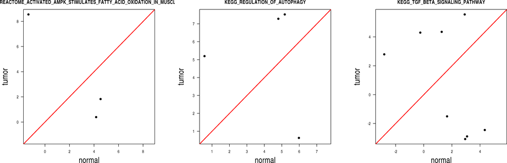

Figure 20: Scatter plots for some interesting pathways with high X2-score

```r
par(mfrow = c(1, 3), mar = c(4, 5, 3, 4))
genesGS1 <- colnames(Im)[which(Im[names(rnkGSx)[1], ] == 1)]
genesGS2 <- colnames(Im)[which(Im[names(rnkGSx)[45], ] == 1)]
genesGS3 <- colnames(Im)[which(Im[names(rnkGSx)[36], ] == 1)]
plotGS(se.filt4, genesGS1, "type", main = names(rnkGSx)[1], cex.lab = 2, las = 1)
plotGS(se.filt4, genesGS2, "type", main = names(rnkGSx)[45], cex.lab = 2, las = 1)
plotGS(se.filt4, genesGS3, "type", main = names(rnkGSx)[36], cex.lab = 2, las = 1)
```

```r
# For loop to plot all interesting pathways
#for (i in pathways){
  #topgsgenes <- colnames(Im)[which(Im[names(rnkGSx)[i], ] == 1)]
  #plotGS(se.filt4, topgsgenes, "type", main = names(rnkGSx)[i], cex.lab = 2, las = 1)
#}

#write.csv(as.data.frame(DEgs_xS), file = "GSEA_Xscore_5size.csv")
#write.csv(as.data.frame(all_DEgs), file = "GSEA_ALL_5size.csv")
```

## 4.3 Analysis of interesting DEGs and interesting pathways

We can check the p-value and logFC of some particular genes of interest that we know are related to ccRCC. We can do the same for the genes that are involved in a particular pathway of interest.

```r
## Checking the gene composition of a particular interesting pathway

# VEGF PATHWAY
VEGF_genes <- colnames(Im)[which(Im[names(rnkGSz)[33], ] == 1)]
#plotGS(se.filt4, VEGF_genes, "type", main = names(rnkGSz)[33], cex.lab = 2, las = 1)
tt[VEGF_genes,]
```

```
##          chr symbol   logCPM     logFC  AveExpr         t      P.Value
## 26285  chr21 CLDN17 1.830198 -2.722878 1.830564 -17.03161 4.268091e-24
## 9071   chr13 CLDN10 3.619200 -7.972111 3.618788 -25.48535 5.862799e-33
## 149461  chr1 CLDN19 3.023070 -6.743905 3.024178 -28.44984 1.683416e-35
## 24146   chr7 CLDN15 1.994124 -3.177797 1.994949 -18.55268 6.641766e-26
## 53842   chr4 CLDN22 3.292640 -6.091944 3.293257 -18.90976 2.589467e-26
## 5010    chr3 CLDN11 4.090766 -7.892963 4.090530 -27.51402 1.006996e-34
## 23562  chr21 CLDN14 6.106016 -2.245342 6.106052 -26.82409 3.894766e-34
## 1495    chr5 CTNNA1 2.749296  2.983573 2.749886  14.86397 2.530237e-21
## 1004    chr5   CDH6 2.782295 -4.250720 2.782908 -26.86375 3.600517e-34
## 1007    chr5   CDH9 7.384808  2.545623 7.384803  21.41705 4.919444e-29
## 1005   chr18   CDH7 2.054960  3.569353 2.056285  11.42485 2.098350e-16
##           adj.P.Val        B
## 26285  2.827716e-23 44.49314
## 9071   1.729007e-31 64.91814
## 149461 9.630874e-34 70.73575
## 24146  5.624825e-25 48.65410
## 53842  2.307325e-25 49.59483
## 5010   4.628708e-33 68.97133
## 23562  1.578031e-32 67.35493
## 1495   1.202923e-20 37.95253
## 1004   1.463259e-32 67.70216
## 1007   6.924624e-28 55.45247
## 1005   6.427163e-16 26.63202
```

```r
# CELL CYCLE
CC_genes <- colnames(Im)[which(Im[names(rnkGSz)[49], ] == 1)]
#plotGS(se.filt4, CC_genes, "type", main = names(rnkGSz)[49], cex.lab = 2, las = 1)
tt[CC_genes,]
```

```
##        chr symbol     logCPM     logFC    AveExpr         t      P.Value
## 3098 chr10    HK1  0.4491100 -8.756576  0.4848273 -30.64658 3.067741e-37
## 5213 chr12   PFKM -0.1419118 -5.947511 -0.1367812 -20.00384 1.563631e-27
## 5208  chr1 PFKFB2  2.4301440 -2.073938  2.4305300 -17.69026 6.824455e-25
##         adj.P.Val        B
## 3098 2.781836e-35 74.48002
## 5213 1.689076e-26 52.47363
## 5208 5.025878e-24 46.24904
```

```r
# PI3K pathway
#PI3K_genes <- colnames(Im)[which(Im[names(rnkGSz)[76], ] == 1)]
#plotGS(se.filt4, PI3K_genes, "type", main = names(rnkGSz)[76], cex.lab = 2, las = 1)
#tt[PI3K_genes,]

# AKT pathway
#AKT_genes <- colnames(Im)[which(Im[names(rnkGSz)[111], ] == 1)]
#plotGS(se.filt4, AKT_genes, "type", main = names(rnkGSz)[111], cex.lab = 2, las = 1)
#tt[AKT_genes,]

# MTOR pathway
#MTOR_genes <- colnames(Im)[which(Im[names(rnkGSz)[341], ] == 1)]
#plotGS(se.filt4, MTOR_genes, "type", main = names(rnkGSz)[341], cex.lab = 2, las = 1)
#tt[MTOR_genes,]

## Checking the logFC and adjusted p-value of particular interesting DEGs
tt[tt$symbol %in% c("HIF1A","EPAS1","VEGFA","PRKAA1","PTEN","PRKAA1","BAP1","PBRM1","SETD2"),]
```

```
##         chr symbol    logCPM      logFC   AveExpr          t      P.Value
## 29072  chr3  SETD2 2.1424745  3.0369241 2.1424081  28.234313 2.529986e-35
## 55193  chr3  PBRM1 3.0253574  3.5923000 3.0253239  22.842789 1.790318e-30
## 5728  chr10   PTEN 5.3338913 -0.7640392 5.3339217 -15.810136 1.455803e-22
## 3091  chr14  HIF1A 4.6047887  1.5396721 4.6048016  15.007231 1.630628e-21
## 5562   chr5 PRKAA1 1.3417435 -1.2833343 1.3432320 -13.278990 3.877795e-19
## 2034   chr2  EPAS1 0.6575582 -2.5978445 0.6645385 -12.233477 1.277581e-17
## 7422   chr6  VEGFA 6.1914962  0.4245406 6.1915120   9.573975 1.708119e-13
## 8314   chr3   BAP1 3.4181275  0.2881764 3.4182099   2.974978 4.283032e-03
##          adj.P.Val         B
## 29072 1.370923e-33 70.348513
## 55193 3.242519e-29 59.152455
## 5728  7.992526e-22 40.388912
## 3091  7.930052e-21 38.068369
## 5562  1.502209e-18 33.061204
## 2034  4.326767e-17 29.634293
## 7422  4.148911e-13 19.243605
## 8314  5.382560e-03 -4.020401
```

# References

TCGA, The Cancer Genome Atlas Research Network. 2013. “Comprehensive Molecular Characterization of Clear Cell Renal Cell Carcinoma.” *Nature* 499. The Author(s): 43–49.